# ANOVA-Like Differential Expression tool for high throughput sequencing data

Greg Gloor

Dep't of Biochemistry, University of Western Ontario

ggloor@uwo.ca

24 July 2018

#### Package

ALDEx2 1.10.3

# 1 Why the *ALDEx2* package?

Fundamentally, many high throughput sequencing approaches generate similar data: reads are mapped to features in each sample, these features are normalized, then statistical difference between the features composing each group or condition is calculated. The standard statistical tools used to analyze RNA-seq, ChIP-seq, 16S rRNA gene sequencing, metagenomics, etc. are fundamentally different for each approach despite the underlying similarity in the data structures. In most cases the values expected by, and modelled by, these tools is counts.

Fernandes et al. (2014)

Gierliński et al. (2015)

Fernandes et al. (2013);Fernandes et al. (2014)

# 2 Introduction to *ALDEx2*

This guide provides an overview of the R package ALDEx version 2 (*ALDEx2*) for differential (relative) abundance analysis of proportional data. The package was developed and used initially for multiple-organism RNA-Seq data generated by high-throughput sequencing platforms (meta-RNA-Seq), but testing showed that it performed very well with traditional RNA-Seq datasets, 16S rRNA gene variable region sequencing and selective growth-type (SELEX) experiments. In principle, the analysis method should be applicable to nearly any type of data that is generated by high-throughput sequencing that generates tables of per-feature counts for each sample(Fernandes et al. 2014): in addition to the examples outlined above this would include ChIP-Seq or metagenome sequencing. We will be including examples and citations for application on these types of problems as we move forward.

all high throughput sequencing data are compositional (Gloor et al. 2017) because of constraints imposed by the instruments

Macklaim et al. (2013)

Quinn, Crowley, and Richardson (2018)

Bian et al. (n.d.)

McMurrough et al. (2014);Wolfs et al. (2016)

The *ALDEx2* package in Bioconductor is modular and is suitable for the comparison of many different experimental designs. This is achieved by exposing the underlying centre log-ratio transformed Dirichlet Monte-Carlo replicate values to make it possible for anyone to add the specific R code for their experimental design — a guide to these values is outlined below.

*ALDEx2* estimates per-feature technical variation within each sample using Monte-Carlo instances drawn from the Dirichlet distribution. This distribution maintains the proportional nature of the data and returns a multivariate probability distribution. *ALDEx2* uses the centred log-ratio (clr) transformation that ensures the data are scale invariant and sub-compositionally coherent. The scale invariance property removes the need for a between sample data normalization step since the data are all placed on a consistent numerical co-ordinate. The sub-compositional coherence property ensures that the answers obtained are consistent when parts of the dataset are removed (e.g., removal of rRNA reads from RNA-seq studies or rare OTU species from 16S rRNA gene amplicon studies). All feature abundance values are expressed relative to the geometric mean abundance of all features in a sample. This is conceptually similar to a quantitative PCR where abundances are expressed relative to a standard: in the case of the clr transformation, the standard is the per-sample geometric mean abundance. See Aitchison (1986) for a complete description.

Aitchison (1986)

In extreme cases we observe that the centre log-ratio can be asymmetric in the data. This occurs when the data are extremely asymmetric, such as when one group is largely composed of features that are absent in the other group. In this case the geometric mean will not accurately represent the appropriate basis of comparison for each group. *ALDEx2* incorporates four methods to deal with this^(Wu et al (in prep)). The first is to include as the denominator for the geometric mean those features that are relatively invariant across all samples. This is termed the ‘iqlr’ method, and takes as the denominator the geometric mean of those features with variance calculated from the clr that are between the first and third quartile. This approach can be used until the asymmetry becomes so severe that more than 25% of the features are asymmetric between the groups. The iqlr approach has the advantage that it gives essentially the same answer as using the entire set of features in symmetric datasets. The second approach, termed the ‘zero’ approach uses a different denominator for each group. The per-group denominator is the set of non-zero features in the group. This method introduces much stronger assumptions, but is helpful when the two groups under comparison are very different. The third approach, termed the ‘lvha’ approach identifies those features that are in the bottom quartile in variance across samples and are in the top quartile in relative abundance in every sample. This approach attempts to find ‘housekeeping’ features akin to those used as internal standards for qPCR. The final approach allows the user to specify a vector of row indices for the input data that are to be used as the denominator. In this case, the user is making an assumption regarding which features are invariant. In the case of RNA-seq, this might include a set of `housekeeping’ genes that are though to be invariant under the perturbation being tested. IMPORTANT: all rows must contain one or more counts when the user defines the row indices to ensure the appropriate rows are chosen.

# 3 Ways to install

There are multiple ways to download and install the most current of *ALDEx2*. *ALDEx2* will run with only the base R packages and is capable of running several functions with the `parallel’ package if installed. It has been tested with version R version 3, but should run on version 2.12 onward. It is recommended that the package be run on the most up-to-date R and Bioconductor versions. *ALDEx2* will make use of the BiocParallel package if possible, otherwise, *ALDEx2* will run in serial mode.

# 4 `aldex` with 2 groups:

*ALDEx2* contains an `aldex` wrapper function that can perform many simple analyses. This wrapper will link the modular elements together to emulate *ALDEx2* prior to the modular approach. Note that if the test is ‘kw’, then `effect` should be FALSE. If the test is ‘t’, then effect should be set to `TRUE`. The ‘t’ option evaluates the data as a two-factor experiment using both the Welch’s t and the Wilcoxon rank tests. The ‘kw’ option evaluates the data as a one-way ANOVA using the glm and Kruskal-Wallace tests. All tests include a Benjamini-Hochberg correction of the raw P values. The data can be plotted onto Bland-Altmann (MA) or effect (MW) plots for for two-way tests using the `aldex.plot` function. See the end of the modular section for examples of the plots.

Altman and Bland (1983)

Gloor, Macklaim, and Fernandes (2016)

Case study a growth selection type (SELEX) experiment. This section contains an analysis of a dataset collected where a single gene library was made that contained 1600 sequence variants at 4 codons in the sequence. These variants were cloned into an expression vector at equimolar amounts. The wild-type version of the gene conferred resistance to a topoisomerase toxin. Seven independent growths of the gene library were conducted under selective and non-selective conditions and the resulting abundances of each variant was read out by sequencing a pooled, barcoded library on an Illumina MiSeq. The data table is included as selex_table.txt in the package. In this data table, there are 1600 features and 14 samples. The analysis takes approximately 2 minutes and memory usage tops out at less than 1Gb of RAM on a mobile i7 class processor when we use 128 Dirichlet Monte-Carlo Instances (DMC). For speed concerns we use only the first 400 features and perform only 16 DMC. The command used for *ALDEx2* is presented below:

McMurrough et al. (2014)

First we load the library and the included selex dataset. Then we set the comparison groups. This must be a vector of conditions in the same order as the samples in the input counts table. The `aldex` command is calling several other functions in the background, and each of them returns diagnostics.

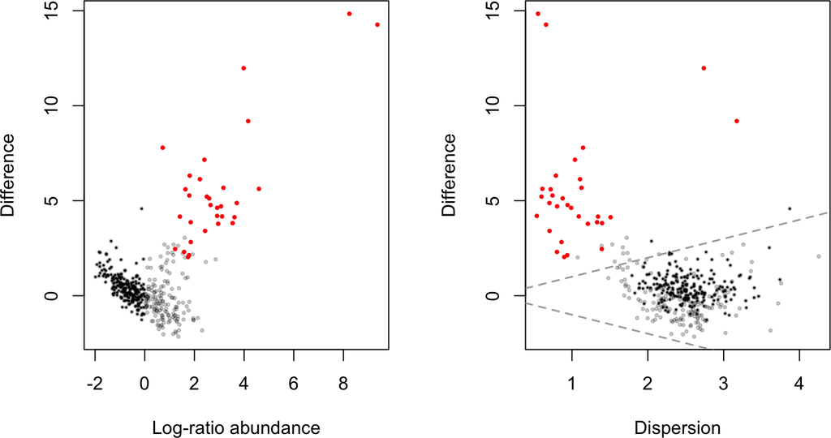

Figure 1: MA and Effect plots of ALDEx2 output  
The left panel is an Bland-Altman or MA plot that shows the relationship between abundance and Difference. The right panel is an effect plot that shows the relationship between Difference and Dispersion. In both plots features that are not significant are in grey or black. Features that are statistically significant are in red. The Log-ratio abundance axis is the clr value for the feature.

```r
library(ALDEx2)
data(selex)
#subset only the last 400 features for efficiency
selex.sub <- selex[1:400,]

conds <- c(rep("NS", 7), rep("S", 7))
x.all <- aldex(selex.sub, conds, mc.samples=16, test="t", effect=TRUE,
     include.sample.summary=FALSE, denom="all", verbose=FALSE)

par(mfrow=c(1,2))
aldex.plot(x.all, type="MA", test="welch", xlab="Log-ratio abundance",
    ylab="Difference")
aldex.plot(x.all, type="MW", test="welch", xlab="Dispersion",
    ylab="Difference")
```

# 5 Using *ALDEx2* modules

The modular approach exposes the underlying intermediate data so that users can generate their own tests. The simple approach outlined above just calls `aldex.clr, aldex.ttest, aldex.effect` in turn and then merges the data into one object. We will show these modules in turn, and then examine additional modules.

## 5.1 The `aldex.clr` module

This operation is fast.

```r
x <- aldex.clr(selex.sub, conds, mc.samples=16, denom="all", verbose=F)
```

## 5.2 The `aldex.ttest` module

The next operation performs the Welch’s t and Wilcoxon rank test for the instance when there are only two conditions. There are three inputs: the aldex object from `aldex.clr`, the vector of conditions, whether a paired test should be conducted or not (TRUE or FALSE).

This operation is reasonably fast.

```r
x.tt <- aldex.ttest(x, conds, paired.test=FALSE, verbose=FALSE)
```

## 5.3 The `aldex.kw` module

Alternatively to the t-test, the user can perform the glm and Kruskal Wallace tests for one-way ANOVA of two or more conditions. Here there are only two inputs: the aldex object from aldex.clr, and the vector of conditions. Note that this is slow! and is not evaluated for this documentation.

```r
x.kw <- aldex.kw(x, conds)
```

## 5.4 The `aldex.effect` module

Finally, we estimate effect size and the within and between condition values in the case of two conditions. This step is required for plotting. There are four inputs: the aldex object from aldex.clr, the vector of conditions, a flag as to whether to include values for all samples or not are used as the denominator, and the level of verbosity.

```r
x.effect <- aldex.effect(x, conds, verbose=FALSE)
```

## 5.5 The `aldex.plot` module

Finally, the t-test and effect data are merged into one object.

```r
x.all <- data.frame(x.tt,x.effect)
```

And the data are plotted. We see that the plotted data in Figure 1 and 2 are essentially the same.

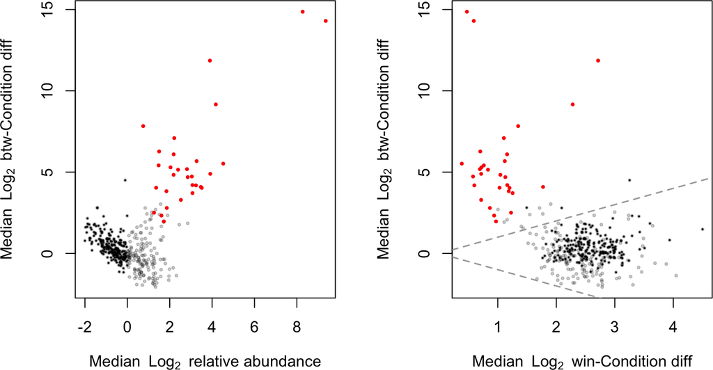

Figure 2: Output from aldex  
plot function. The left panel is the MA plot, the right is the MW (effect) plot. In both plots red represents features called as differentially abundant with q $<0.1$; grey are abundant, but not non-differentially abundant; black are rare, but not differentially abundant. This function uses the combined output from the aldex.ttest and aldex.effect functions

```r
par(mfrow=c(1,2))
aldex.plot(x.all, type="MA", test="welch")
aldex.plot(x.all, type="MW", test="welch")
```

## 5.6 Complex study designs and the aldex.glm module

The aldex.glm module has been included so that the probabilistic compositional approach can be used for complex study designs. This module is substantially slower than the two-comparison tests above, but we think it is worth it if you have complex study designs.

Essentially, the approach is the modular approach above but using a model matrix and covariates supplied to the glm function in R. The values returned are the expected values of the glm function given the inputs. In the example below, we are measuring the predictive value of variables A and B independently. See the documentation for the R formula function, or http://faculty.chicagobooth.edu/richard.hahn/teaching/formulanotation.pdf for more information.

Validation of features that are differential under any of the variables identified by the aldex.glm function should be performed using the aldex.effect function as a post-hoc test.

```r
 covariates <- data.frame("A" = sample(0:1, 14, replace = TRUE),
     "B" = c(rep(0, 7), rep(1, 7)))
 mm <- model.matrix(~ A + B, covariates)
 x <- aldex.clr(selex.sub, mm, mc.samples=8, denom="all")
```

```
## [1] "conditions provided as matrix: selecting first column for aldex.clr"
```

```
## operating in serial mode
```

```
## computing center with all features
```

```r
 glm.test <- aldex.glm(x, mm)
```

```
## |------------(25%)----------(50%)----------(75%)----------|
```

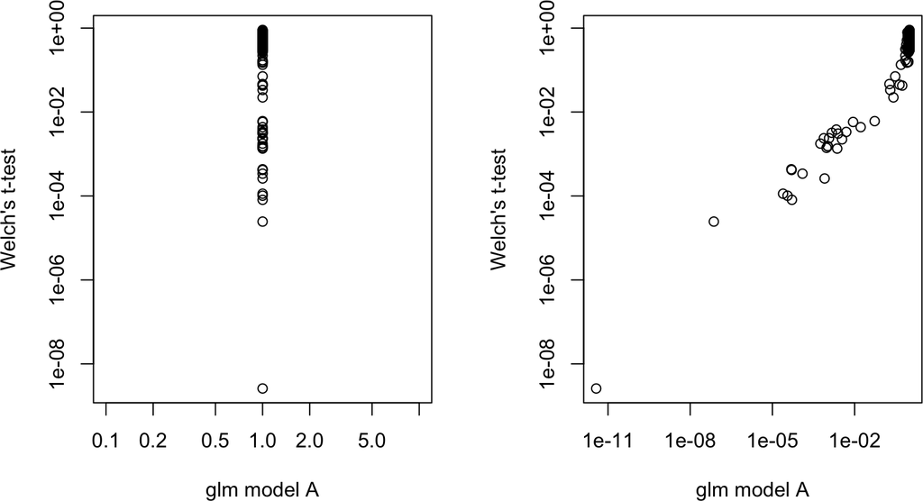

Figure 3: Comparing the glm and t-test  
Plots of the expected P values for variables output from the glm function with model A (random predictors), and model B (actual study design groups) compared to the P values output by the Welch’s t-test. This toy model shows how to use a generalized linear model within theALDEx2 framework. All values are the expected value of the test statistic after correction for multiple hypothesis testing.

```r
 par(mfrow=c(1,2))
 plot(glm.test[,"model.A Pr(>|t|).BH"], x.all$we.eBH, log="xy",
     xlab="glm model A", ylab="Welch's t-test")
 plot(glm.test[,"model.B Pr(>|t|).BH"], x.all$we.eBH, log="xy",
     xlab="glm model A", ylab="Welch's t-test")
```

# 6 ALDEx2 outputs

## 6.1 Expected values

Several papers have suggested that *ALDEx2* is unable to properly control for the false discovery rate since the P values returned do not follow a random uniform distribution, but rather tend to cluster near a value of 0.5Thorsen et al. (2016). These studies indicate that point estimate approaches are very sensitive to particular experimental designs and differences in sparsity and read depth. However, *ALDEx2* is not sensitive to these characteristics of the data, but seem to under-report the true FDR. The criticisms miss the mark on *ALDEx2* because *ALDEx2* reports the P value across the Dirichlet Monte-Carlo replicates. Features that are differential simply because of the vagaries of random sampling will indeed have a random uniform P value as point estimates, but will have an expected P value after repeated random sampling of 0.5. In contrast, features that are differential because of true biological variation are robust to repeated random sampling. Thus, *ALDEx2* identifies as differential only those features where simple random sampling (the minimal NULL hypothesis) cannot explain the difference.

Hawinkel et al. (2018);

In our experience, we observe that *ALDEx2* returns a set of features that is very similar to the set returned as the intersect of multiple independent tools—a common recommendation when examining HTS datasets

Soneson and Delorenzi (2013)

## 6.2 Explaining the outputs

| variant | we.ep | we.eBH | wi.ep | wi.eBH | kw.ep |
| --- | --- | --- | --- | --- | --- |
| A:D:A:D | 4.03010e-01 | 0.63080705 | 0.239383012 | 0.43732819 | 0.21532060 |
| A:D:A:E | 1.15463e-01 | 0.34744596 | 0.040901806 | 0.15725841 | 0.03745315 |
| A:E:A:D | 8.98797e-05 | 0.00329076 | 0.000582750 | 0.00820759 | 0.00174511 |

| variant | kw.eBH | glm.ep | glm.eBH | rab.all | rab.win.NS | rab.win.S |
| --- | --- | --- | --- | --- | --- | --- |
| A:D:A:D | 0.3932743 | 3.61061e-01 | 5.23582e-01 | 1.42494 | 1.30886 | 2.45384 |
| A:D:A:E | 0.1486590 | 8.12265e-02 | 1.92292e-01 | 1.71230 | 1.49767 | 4.23315 |
| A:E:A:D | 0.0245786 | 7.73660e-08 | 3.35492e-06 | 3.97484 | 1.41163 | 11.02154 |

| variant | diff.btw | diff.win | effect | overlap |
| --- | --- | --- | --- | --- |
| A:D:A:D | 1.12261 | 1.72910 | 0.471043 | 0.267260701 |
| A:D:A:E | 2.73090 | 2.38134 | 1.034873 | 0.135857781 |
| A:E:A:D | 9.64287 | 2.85008 | 3.429068 | 0.000156632 |

In the list below, the `aldex.ttest` function returns the values highlighted with $\ast$, the `aldex.kw` function returns the values highlighted with $\circ$, and the `aldex.effect` function returns the values highlighted with $\diamondsuit$.

1. $\ast$ we.ep - Expected P value of Welch’s t test
2. $\ast$ we.eBH - Expected Benjamini-Hochberg corrected P value of Welch’s t test
3. $\ast$ wi.ep - Expected P value of Wilcoxon rank test
4. $\ast$ wi.eBH - Expected Benjamini-Hochberg corrected P value of Wilcoxon test
5. $\circ$ kw.ep - Expected P value of Kruskal-Wallace test
6. $\circ$ kw.eBH - Expected Benjamini-Hochberg corrected P value of Kruskal-Wallace test
7. $\circ$ glm.ep - Expected P value of glm test
8. $\circ$ glm.eBH - Expected Benjamini-Hochberg corrected P value of glm test
9. $\diamondsuit$ rab.all - median clr value for all samples in the feature
10. $\diamondsuit$ rab.win.NS - median clr value for the NS group of samples
11. $\diamondsuit$ rab.win.S - median clr value for the S group of samples
12. $\diamondsuit$ rab.X1_BNS.q50 - median expression value of features in sample X1_BNS if `include.item.summary=TRUE`
13. $\diamondsuit$ dif.btw - median difference in clr values between S and NS groups
14. $\diamondsuit$ dif.win - median of the largest difference in clr values within S and NS groups
15. $\diamondsuit$ effect - median effect size: diff.btw / max(diff.win) for all instances
16. $\diamondsuit$ overlap - proportion of effect size that overlaps 0 (i.e. no effect)

The built-in aldex.plot function described above will usually be sufficient, but for more user control the example in Figure 4 shows a plot that shows which features are found by the Welchs’ or Wilcoxon test individually (blue) or by both (red).

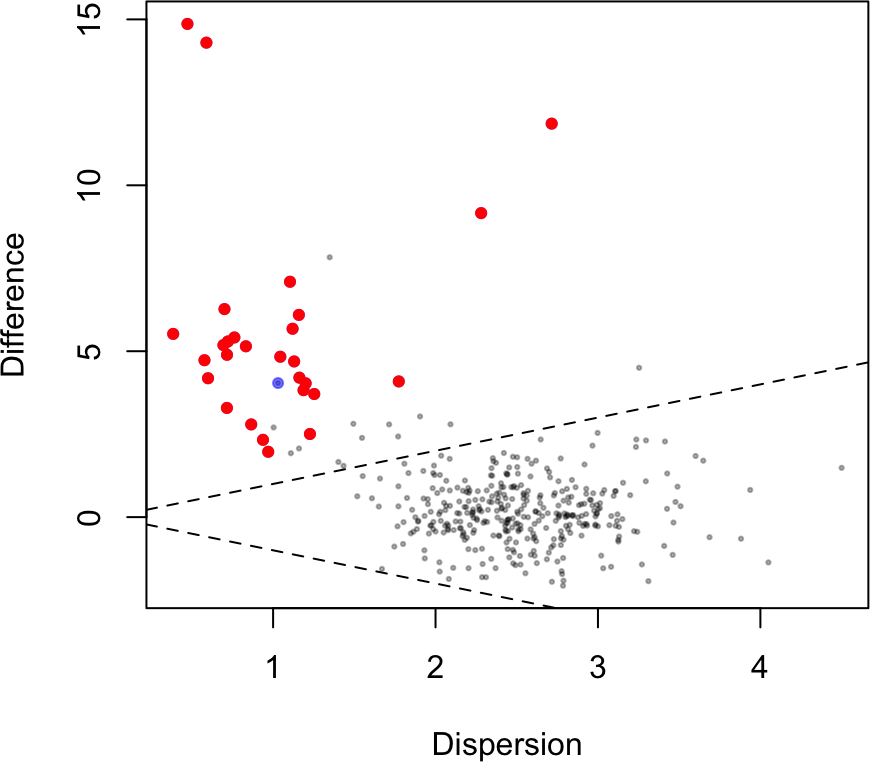

Figure 4: Differential abundance in the selex dataset using the Welch’s t-test or Wilcoxon rank test  
Features identified by both tests shown in red. Features identified by only one test are shown in blue dots. Non-significant features represent rare features if black and abundant features if grey dots.

```r
# identify which values are significant in both the t-test and glm tests
found.by.all <- which(x.all$we.eBH < 0.05 & x.all$wi.eBH < 0.05)

# identify which values are significant in fewer than all tests
found.by.one <- which(x.all$we.eBH < 0.05 | x.all$wi.eBH < 0.05)

# plot the within and between variation of the data
plot(x.all$diff.win, x.all$diff.btw, pch=19, cex=0.3, col=rgb(0,0,0,0.3),
 xlab="Dispersion", ylab="Difference")
points(x.all$diff.win[found.by.one], x.all$diff.btw[found.by.one], pch=19,
 cex=0.7, col=rgb(0,0,1,0.5))
points(x.all$diff.win[found.by.all], x.all$diff.btw[found.by.all], pch=19,
 cex=0.7, col=rgb(1,0,0,1))
abline(0,1,lty=2)
abline(0,-1,lty=2)
```

# 7 Correcting for asymmetric datasets

Asymmetry generally shows as a non-zero mode in the histogram of the x.all$diff.btw or a non-zero mode in the histogram of x.all$effect. We recommend that all datasets be examined for asymmetry.

*ALDEx2* now includes methods to centre the data properly when the dataset contains an asymmetry between the groups. An asymmetry can arise for many reasons: in RNA-seq it could arise because samples in one group contain a plasmid and the samples in the other group do not; in metagenomics or 16S rRNA gene sequencing it can arise when the samples in the two groups are taken from different environments; in a selex experiment it can arise because the two groups are under different selective constraints. The asymmetry can manifest either as a difference in sparsity (i.e., one group contains more 0 value features than the other) or as a systematic difference in abundance. When this occurs the geometric mean of each group can be markedly different, and thus an inherent skew in the dataset can occur that leads to false positive and false negative feature calls.

## 7.1 Methods to correct for asymmetry

Figure 5 shows the effect of the iqlr correction on the example dataset. When the denominator is all, we see that the bulk of the points fall off the midpoint (dotted line), but that the bulk of the points are centered around 0 for the iqlr and lvha analysis. Thus, we have a demonstrably better centring of the data in the latter two methods. Practically speaking, we alter the p values and effect sizes of features near the margin of significance following iqlr or lvha transformation. The effect is largest for those features that are close to the bulk datapoints.

First the code:

```
## operating in serial mode
```

```
## computing center with all features
```

```
## operating in serial mode
## operating in serial mode
```

```
## computing iqlr centering
```

```
## operating in serial mode
## operating in serial mode
```

```
## computing center with housekeeping features
```

```
## operating in serial mode
```

[figure not shown]

Figure 5: Differential abundance in a synthetic dataset using different denominators for the clr calculation  
In this data 2% of the features are modelled to be sparse in one group but not the other. Features modelled to be different between two groups are shown in red. Features that are non-significant are in grey (or brown). Features used in the denominator shown in brown: the geometric mean of these features is used as the denominator when calculating the clr transformation. Lines of constant effect are drawn at 0, and $\pm$ 1. Note that the iqlr and lvha denominators place the middle of the non-asymmetric features at a between group difference of 0.

```r
# small synthetic dataset for illustration
# denominator features in x@denominator

data(synth2)
blocks <- c(rep("N", 10),rep("S", 10))
x <- aldex.clr(synth2, blocks, denom="all")
x.e <- aldex.effect(x, blocks)
plot(x.e$diff.win, x.e$diff.btw, pch=19, col=rgb(0,0,0,0.1), cex=0.5, xlab="dispersion", ylab="difference", main="all")
points(x.e$diff.win[x@denom], x.e$diff.btw[x@denom], pch=19, col=rgb(0.8,0.5,0,0.7), cex=0.5)
points(x.e$diff.win[47:86], x.e$diff.btw[47:86], col=rgb(0.8,0,0,0.7), cex=0.5)
points(x.e$diff.win[980:1000], x.e$diff.btw[980:1000], col=rgb(0.8,0,0,0.7), cex=0.5)
abline(0,1)
abline(0,-1)
abline(h=0, col="gray", lty=2)
```

# 8 Contributors

I am grateful that *ALDEx2* has taken on a life of its own.

- Andrew Fernandes wrote the original ALDEx code, and designed *ALDEx2*.
- Jean Macklaim found and squished many bugs, performed unit testing, did much of the original validation. Jean also made seminal contributions to simplifying and explaining the output of *ALDEx2*.
- Matt Links incorporated several *ALDEx2* functions into a multicore environment.
- Adrianne Albert wrote the correlation and the one-way ANOVA modules in aldex.kw.
- Ruth Grace Wong added function definitions and made the parallel code functional with BioConducter.
- Jia Rong Wu developed and implemented the alternate denominator method to correct for asymmetric datasets.
- Andrew Fernandes, Jean Macklaim and Ruth Grace Wong contributed to the Sum-FunctionsAitchison.R code.
- Tom Quinn rewrote the t-test and Wilcoxon functions to make them substantially faster. He also wrote the current aldex.glm function. Tom’s *propr* R package is able to use the output from aldex.clr.

  Quinn et al. (2017)
- Vladimir Mikryukov and everyone named above have contributed bug fixes
- Greg Gloor currently maintains *ALDEx2* and had and has roles in documentation, design, testing and implementation.

# 9 Version information

Macklaim et al. (2013);Fernandes et al. (2013)

Versions 2.0 to 2.05 were development versions that enabled P value calculations. Version 2.06 of *ALDEx2* was the version used for the analysis in. This version enabled large sample comparisons by calculating effect size from a random sample of the data rather than from an exhaustive comparison.

Fernandes et al. (2014)

Version 2.07 of *ALDEx2* was the initial the modular version that exposed the intermediate calculations so that investigators could write functions to analyze different experimental designs. As an example, this version contains an example one-way ANOVA module. This is identical to the version submitted to Bioconductor as 0.99.1.

Future releases of *ALDEx2* now use the Bioconductor versioning numbering.

Aitchison, J. 1986. *The Statistical Analysis of Compositional Data*. London, England: Chapman & Hall.

Altman, D. G., and J. M. Bland. 1983. “Measurement in Medicine: The Analysis of Method Comparison Studies.” *Journal of the Royal Statistical Society. Series D (the Statistician)* 32 (3). Wiley for the Royal Statistical Society:pp. 307–17. http://www.jstor.org/stable/2987937.

Bian, Gaorui, Gregory B Gloor, Aihua Gong, Changsheng Jia, Wei Zhang, Jun Hu, Hong Zhang, et al. n.d. “The Gut Microbiota of Healthy Aged Chinese Is Similar to That of the Healthy Young.” *mSphere* 2 (5):e00327–17. https://doi.org/10.1128/mSphere.00327-17.

Fernandes, Andrew D, Jean M Macklaim, Thomas G Linn, Gregor Reid, and Gregory B Gloor. 2013. “ANOVA-Like Differential Expression (Aldex) Analysis for Mixed Population Rna-Seq.” *PLoS One* 8 (7):e67019. https://doi.org/10.1371/journal.pone.0067019.

Fernandes, Andrew D, Jennifer Ns Reid, Jean M Macklaim, Thomas A McMurrough, David R Edgell, and Gregory B Gloor. 2014. “Unifying the Analysis of High-Throughput Sequencing Datasets: Characterizing RNA-Seq, 16S RRNA Gene Sequencing and Selective Growth Experiments by Compositional Data Analysis.” *Microbiome* 2:15.1–15.13. https://doi.org/10.1186/2049-2618-2-15.

Gierliński, Marek, Christian Cole, Pietà Schofield, Nicholas J Schurch, Alexander Sherstnev, Vijender Singh, Nicola Wrobel, et al. 2015. “Statistical Models for Rna-Seq Data Derived from a Two-Condition 48-Replicate Experiment.” *Bioinformatics* 31 (22):3625–30. https://doi.org/10.1093/bioinformatics/btv425.

Gloor, Gregory B., Jean M. Macklaim, Vera Pawlowsky-Glahn, and Juan J. Egozcue. 2017. “Microbiome Datasets Are Compositional: And This Is Not Optional.” *Frontiers in Microbiology* 8:2224. https://doi.org/10.3389/fmicb.2017.02224.

Gloor, Gregory B, Jean M. Macklaim, and Andrew D. Fernandes. 2016. “Displaying Variation in Large Datasets: Plotting a Visual Summary of Effect Sizes.” *Journal of Computational and Graphical Statistics* 25 (3C):971–79. https://doi.org/10.1080/10618600.2015.1131161.

Hawinkel, Stijn, Federico Mattiello, Luc Bijnens, and Olivier Thas. 2018. “A Broken Promise : Microbiome Differential Abundance Methods Do Not Control the False Discovery Rate.” *BRIEFINGS IN BIOINFORMATICS*. http://dx.doi.org/10.1093/bib/bbx104.

Macklaim, M Jean, D Andrew Fernandes, M Julia Di Bella, Jo-Anne Hammond, Gregor Reid, and Gregory B Gloor. 2013. “Comparative Meta-RNA-Seq of the Vaginal Microbiota and Differential Expression by *Lactobacillus Iners* in Health and Dysbiosis.” *Microbiome* 1:15. https://doi.org/doi: 10.1186/2049-2618-1-12.

McMurrough, Thomas A, Russell J Dickson, Stephanie M F Thibert, Gregory B Gloor, and David R Edgell. 2014. “Control of Catalytic Efficiency by a Coevolving Network of Catalytic and Noncatalytic Residues.” *Proc Natl Acad Sci U S A* 111 (23):E2376–83. https://doi.org/10.1073/pnas.1322352111.

Quinn, Thomas P, Tamsyn M Crowley, and Mark F Richardson. 2018. “Benchmarking Differential Expression Analysis Tools for Rna-Seq: Normalization-Based Vs. Log-Ratio Transformation-Based Methods.” *BMC Bioinformatics* 19 (1):274. https://doi.org/10.1186/s12859-018-2261-8.

Quinn, Thomas, Mark F Richardson, David Lovell, and Tamsyn Crowley. 2017. “Propr: An R-Package for Identifying Proportionally Abundant Features Using Compositional Data Analysis.” *bioRxiv*. Cold Spring Harbor Labs Journals. https://doi.org/10.1101/104935.

Soneson, Charlotte, and Mauro Delorenzi. 2013. “A Comparison of Methods for Differential Expression Analysis of RNA-seq Data.” *BMC Bioinformatics* 14:91. https://doi.org/10.1186/1471-2105-14-91.

Thorsen, Jonathan, Asker Brejnrod, Martin Mortensen, Morten A Rasmussen, Jakob Stokholm, Waleed Abu Al-Soud, Søren Sørensen, Hans Bisgaard, and Johannes Waage. 2016. “Large-Scale Benchmarking Reveals False Discoveries and Count Transformation Sensitivity in 16S RRNA Gene Amplicon Data Analysis Methods Used in Microbiome Studies.” *Microbiome* 4 (1):62. https://doi.org/10.1186/s40168-016-0208-8.

Wolfs, Jason M, Thomas A Hamilton, Jeremy T Lant, Marcon Laforet, Jenny Zhang, Louisa M Salemi, Gregory B Gloor, Caroline Schild-Poulter, and David R Edgell. 2016. “Biasing Genome-Editing Events Toward Precise Length Deletions with an Rna-Guided Tevcas9 Dual Nuclease.” *Proc Natl Acad Sci U S A*, December. https://doi.org/10.1073/pnas.1616343114.